# Epidemiology Notes 2012-10-11

When to screen *Contagion*?

- Another movie about epidemics: a comparison of smallpox in Montreal in 1885 and a hypothetical outbreak today. [on Netflix](http://movies.netflix.com/WiMovie/Outbreak_Anatomy_of_a_Plague/70243165?trkid=7728649)

## Estimation Problem 3

[Straightforward calculation](https://moodle.macalester.edu/mod/assign/view.php?id=20499&sid=4926&gid=4926&plugin=onlinetext&action=viewpluginassignsubmission&returnaction=grading&returnparams=) reduce the number of mosquitos, reduce the number of cases.

[A saturation approach](https://moodle.macalester.edu/mod/assign/view.php?id=20499&sid=8445&gid=8445&plugin=onlinetext&action=viewpluginassignsubmission&returnaction=grading&returnparams=) Assumption: there is redundant biting of people by mosquitos. That is, people get infected by more than one mosquito, so reducing the number of mosquitos doesn’t reduce infection proportionately. Is there redundant biting? If so, why is the prevalence so low?

[A nice approach](https://moodle.macalester.edu/mod/assign/view.php?id=20499&sid=8604&gid=8604&plugin=onlinetext&action=viewpluginassignsubmission&returnaction=grading&returnparams=). But the 5/100 assumption is critical. If we can get the reproduction rate under 1, then the treatment will be effective.

## SIR Model

Three groups: Susceptible, Infected, Recovered

$\frac{dS}{dt} = - \beta S I$  
$\frac{dI}{dt} = \beta S I - \gamma I$  
$\frac{dR}{dt} = \gamma I$

Use the `mSIR( )` manipulate applet in R, install with `source("http://tiny.cc/mosaic/mSIR.R"")`

#### The Tipping Point

Prob. of infection: 0.1 Contacts per Day: 9 Duration of disease decay: .799 Initial infected: 1

About 20% of the population gets the disease.

Explore some policy implications:

- Change contacts per day — big effect
- Change probability of infection — big effect
- Number of initial infected — little effect

What happens as duration is increased? (NOTE: This means lowering the parameter. You can see this by setting probability of infection to 0 and the initial infected to 50 — then the exponential decay of infected shows up directly.

#### Endemic Disease

Prob. of Infection: 0.35 Contacts per day: 5 Duration of disease decay: 0.457 Initial infected: 5 Births/day: 20

## Epiville Case-Control

Work through the [http://ccnmtl.columbia.edu/projects/epiville/case_control_study/ case study].

- Question: How many people to involve in the study?
- Question: How precise are their results?

## Odds Ratios and Logarithms

Suppose you had two different studies, each of which produces an odds ratio different from 1, but where the two different studies have opposite conclusions.

#### Study 1

[output not shown]

Odds Ratio: 4

#### Study 2

[output not shown]

Odds Ratio: 1/4

#### Combine the two Studies

[output not shown]

#### Average the two odds ratios

$(4 + 1/4)/2 = 2.125$

There’s a bias to be larger than 1. We can remove this bias by using logarithms.

Construct a table of logarithms base 10

Construct a table of logarithms base 2

Show that the average works on the log table.

# Confidence Intervals and p-values

You have to have just a little bit of statistics to make sense of the literature. Some of you have already had quite a bit, for instance Math 155. That gives you the technical skills you need. We’re going to talk about concepts but give you one technical skill that will help a lot.

### Standard Errors

- Confidence intervals generally. *The idea of a coverage interval. 95% is typically chosen. Use galton height data to get a confidence interval on the sample mean.* Sampling distribution. Show how to simulate this.
- Confidence intervals on LOG odds ratios. $2 \times \sqrt{1/a +1/b + 1/c + 1/d}$
- Use the data created by

```r
# Demonstrations of the construction of confidence intervals and hypothesis testing.
energy = c(rep( "High", 520),
           rep( "High", 510),
           rep( "High", 210),
           rep( "High", 90),
           rep( "Low", 100),
           rep( "Low", 150),
           rep( "Low", 600),
           rep( "Low", 390) )
activity = c(rep( "Active", 520),
           rep( "Active", 510),
           rep( "Lethargic", 210),
           rep( "Lethargic", 90),
           rep( "Active", 100),
           rep( "Active", 150),
           rep( "Lethargic", 600),
           rep( "Lethargic", 390) )
condition = c(rep( "Disease", 520),
           rep( "Control", 510),
           rep( "Disease", 210),
           rep( "Control", 90),
           rep( "Disease", 100),
           rep( "Control", 150),
           rep( "Disease", 600),
           rep( "Control", 390) )
tab8.4 = data.frame( energy=energy, activity=activity, condition=condition)

# odds ratio from a 2x2 table with condition along the 2nd (horizontal) axis
odds.ratio = function(t){
  return( (t[1,1]/t[2,1])/(t[1,2]/t[2,2]) )
}
```

### Activity: Analyzing your random sample

Here are a bunch of random samples prepared for the class, each with a sample size of 100. Have each person calculate an odds ratio. Then let’s compare them.

Tables to hand out — first page — cut these up and give each student one.

Now have each student calculate the confidence interval on the log odds ratio and translate that back into a confidence interval on the odds ratio itself.

Then do it for the whole data set

```r
with(tab8.4, table(activity,condition))
```

```
##            condition
## activity    Control Disease
##   Active        660     620
##   Lethargic     480     810
```

```r
2*sqrt( 1/660 + 1/620 + 1/810 + 1/480)
```

```
## [1] 0.1605734
```

```r
log(odds.ratio(with(tab8.4, table(activity,condition))))
```

```
## [1] 0.5857685
```

```r
exp( .5858 + c(-1,1)*0.1606)
```

```
## [1] 1.529896 2.109393
```

### Automating the process

```r
odds.ratio(with( tab8.4, table(activity,condition )))
```

```
## [1] 1.796371
```

```r
# Working with a sample of size 100
mysamp = sample( tab8.4, size=100)
with(mysamp, table(condition))
```

```
## condition
## Control Disease
##      40      60
```

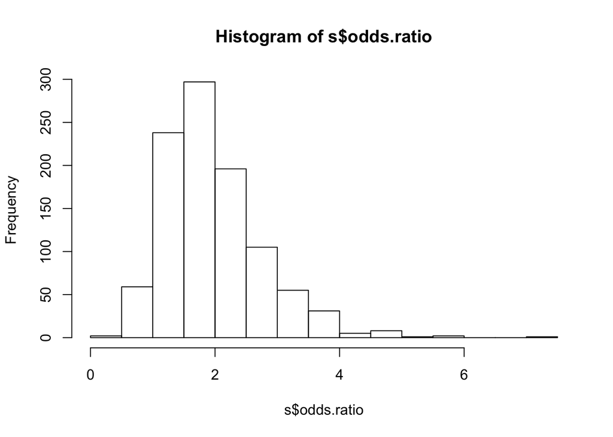

```r
# Construct the sampling distribution from the population
s = do(1000)*odds.ratio(with( sample(tab8.4,size=100), table(activity,condition )))
hist(s$odds.ratio)
```

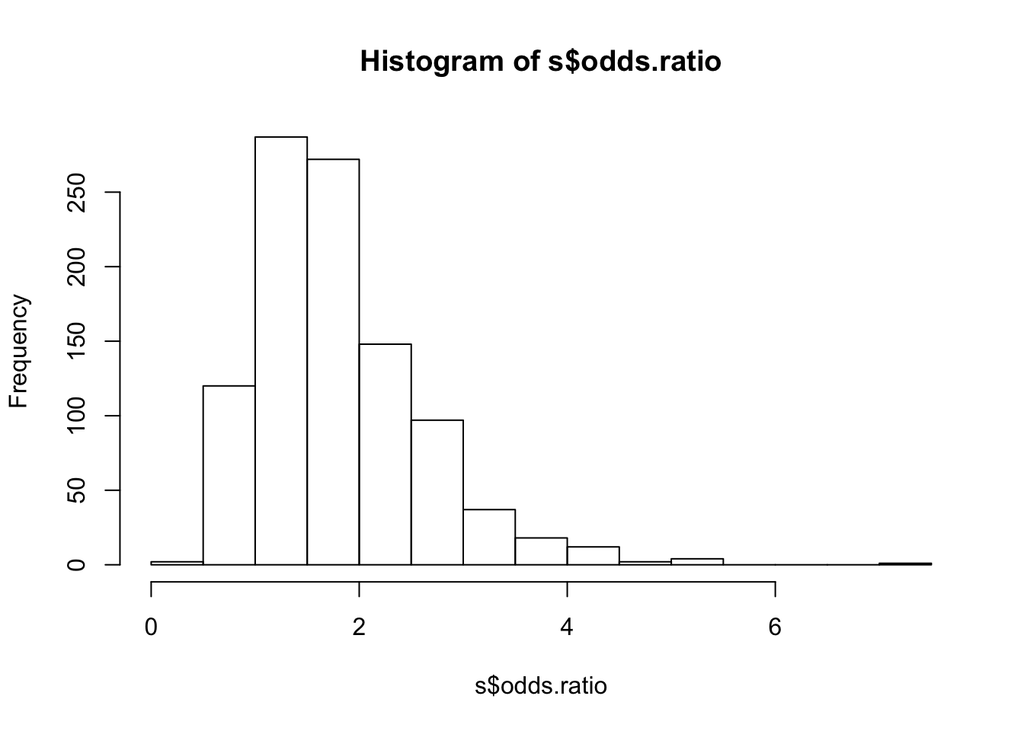

```r
# Construct the resampling distribution from the sample itself
s = do(1000)*odds.ratio(with( resample(mysamp), table(activity,condition )))
hist(s$odds.ratio)
```

```r
qdata(~ odds.ratio, p = c(.025,.975), data = s)
```

```
##        quantile     p
## 2.5%  0.7411765 0.025
## 97.5% 3.8046777 0.975
```

- The standard error and the funnel plot: looking at lots of studies and comparing their odds ratios and standard errors: Start at time 9:30 in [http://www.ted.com/talks/ben_goldacre_battling_bad_science.html this TED video]
- Hypothesis testing. p-values.
  - Same sort of analysis but create a sampling distribution under the Null Hypothesis and ask how likely the observed value is. *Constructing the conditional sampling distribution by randomizing the explanatory variable.* The abuse of p-values and significance. Multiple comparisons. Hand out lists of p-values pages 2 and 3
- Meta-analysis. Advantages and problems (publication bias leading to not all studies being reported).
- Sample size and power.

### Power

How big would the study need to be to keep the confidence intervals well away from log odds of 0.